# Final project

Mohamed, Rayan and Jasmine

## Part 1: Introduction

In September of 2017, Cards Against Humanity’s, “Pulse of th Nation,” partnered with research firm Survey Sampling International to elicit the opinions of thousands of Americans on various social and political topics. The entire project consisted of monthly telephone polls conducted over a two week period to learn the opinions of 1000 Americans. The specific polling data we will be analyzing is from the first poll “Pulse of the Nation” conducted beginning September 15, 2017 and concluded September 30, 2017.

In this project, we will be analyzing the survey responses to answer the question: What factors affect people’s views on climate change? We will specifically be looking at whether or not people believe that climate change is real and caused by humans or not. We will be analyzing how people view science in general and also how party affiliation, age, and other scientific topics may affect a person’s view on climate change.

This project was funded by Cards Against Humanity’s holiday promotion “Cards Against Humanity Saves America,” where people could donate $15 dollars to the company to receive special gifts and prizes.

```
## [1] 1000
```

|  | party | num_of_ind |
| --- | --- | --- |
| 1 | Democrat | 274 |
| 2 | DK/REF | 150 |
| 3 | Independent | 368 |
| 4 | Republican | 208 |

There are 1000 individuals who participated in this survey. There were 274 democrats. 368 Independent (didn’t identify neither as democrat nor a republican) and 150 whose party were unknown

## Part 2: Analysis

### The Relationship between age and Climate Change

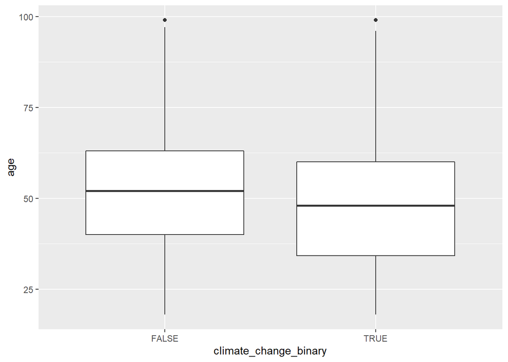

From the boxplot above, it can be seen that younger individuals who were part of the sample believe that climate change is in fact real and caused by people- more than the older individuals. This could stem from various factors, including younger individuals being more exposed to social media platforms and other sources that can shape their opinions on climate change.

To further examine how age is related to views on climate change we will to explore the relationship between age and whether individuals who were part of the survey think that science is honest, to see if that can have an affect on their views on climate change.

In this dataset, the average age of participants is 49 years

| average_age |
| --- |
| 49.408 |

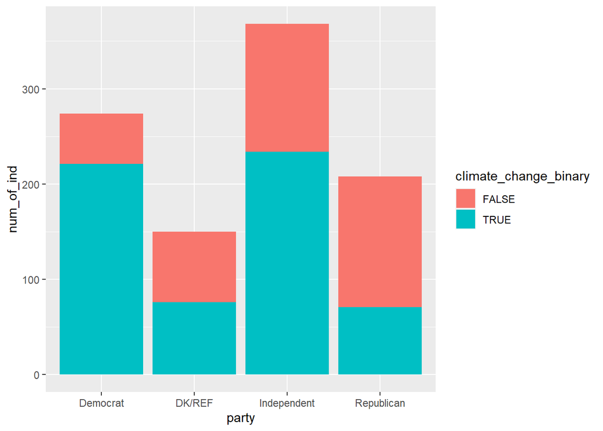

From the bar plot above, the difference in how party affiliation is linked to views on climate change can be observed. It is important to note that these results only represent those who were part of the survey- in which the number of those who identified as Independent (368 individuals) was significantly higher than those who identified as Republican (208), Democrat (274) and Don’t Know (DK)/ Refuse(REF) (150). The TRUE category includes those who believe that climate change is real and caused by people, while the FALSE category includes those who do not think climate change is real as well as people who think climate change is real but not caused by people.

Even so, when looking at the bars individually, in this small sample, there is a much higher number of Independent and Democrat affiliated individuals who view climate change as a real issue that is caused by people. Less than half of those who identify as Republican are in the TRUE category, which calls for further research around the relationship between Party affiliation and belief in climate change.

## Relationship between Age,Climate Change and agreement with the statement “Science is Honest”

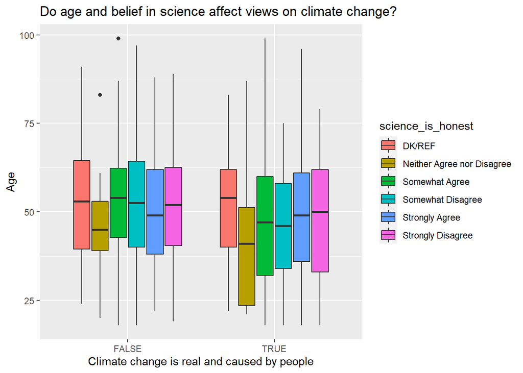

To see if and how age as well as belief in scientists can impact one’s views on climate change. Participants were asked to what degree they agreed with the following statement: “scientists are generally honest and are serving the public good”. While this statement may not fully measure the extent to which a participant believes in science as a whole, it measures the pulse that provide some insights on trends for those who took part of the study.

## Part 3: Collaboration